# Capstone Project - NLP Chatbot

### DOMAIN:

Industrial safety. NLP based Chatbot.

### CONTEXT:

The database comes from one of the biggest industry in Brazil and in the world. It is an urgent need for industries/companies around the globe to understand why employees still suffer some injuries/accidents in plants. Sometimes they also die in such environment.

### DATA DESCRIPTION:

This The database is basically records of accidents from 12 different plants in 03 different countries which every line in the data is an occurrence of an accident.

### Columns description:

- Data: timestamp or time/date information
- Countries: which country the accident occurred (anonymised)
- Local: the city where the manufacturing plant is located (anonymised)
- Industry sector: which sector the plant belongs to
- Accident level: from I to VI, it registers how severe was the accident (I means not severe but VI means very severe)
- Potential Accident Level: Depending on the Accident Level, the database also registers how severe the accident could have been (due to other factors involved in the accident)
- Gender: if the person is male of female
- Employee or Third Party: if the injured person is an employee or a third party
- Critical Risk: some description of the risk involved in the accident
- Description: Detailed description of how the accident happened.

Link to download the dataset: https://drive.google.com/file/d/1_GmrRP1S2OIa02KlfOBNkYa8uxazGbfE/view?usp=sharing, Original dataset link: https://www.kaggle.com/ihmstefanini/industrial-safety-and-health-analytics-database

### PROJECT OBJECTIVE:

Design a ML/DL based chatbot utility which can help the professionals to highlight the safety risk as per the incident description.

```python
from google.colab import drive
drive.mount('/content/drive')
```

Replace the folder path with your drive folder path and clone the githb repo

```python
%cd /content/drive/MyDrive/AIML/Capstone
```

```
/content/drive/MyDrive/AIML/Capstone
```

Run the below code for clone the repo in our Googele drive for first time

```python
! git clone https://github.com/shyamsparrow/Jan-G4---NLP-Chatbot.git
```

```
Cloning into 'Jan-G4---NLP-Chatbot'...
remote: Enumerating objects: 585, done.
remote: Counting objects: 100% (133/133), done.
remote: Compressing objects: 100% (131/131), done.
remote: Total 585 (delta 59), reused 3 (delta 1), pack-reused 452
Receiving objects: 100% (585/585), 252.48 MiB | 13.89 MiB/s, done.
Resolving deltas: 100% (292/292), done.
```

Change the Current folder into Github repo main folder, all the functions we are calling has to be in this repo.

```python
%cd /content/drive/MyDrive/AIML/Capstone/Jan-G4---NLP-Chatbot
```

```
/content/drive/MyDrive/AIML/Capstone/Jan-G4---NLP-Chatbot
```

```python
!git checkout ALL_Models
```

```
Checking out files: 100% (24/24), done.
Branch 'ALL_Models' set up to track remote branch 'ALL_Models' from 'origin'.
Switched to a new branch 'ALL_Models'
```

```python
!git pull
```

```
Already up to date.
```

```python
!git config --global user.email "pradeebha.ab@gmail.com"
!git config --global user.name "Pradeebha"
```

```python
!git status
```

```
On branch ALL_Models
Your branch is up to date with 'origin/ALL_Models'.

nothing to commit, working tree clean
```

```python
!git commit -m "My message"
```

```
On branch ALL_Models
Your branch is up to date with 'origin/ALL_Models'.

nothing to commit, working tree clean
```

Run this code to update the changes in repo to our drive

```python
!git pull
```

```
Already up to date.
```

```python
import warnings
warnings.filterwarnings('ignore')


import string
import numpy as np
import pandas as pd
import seaborn as sns
import matplotlib.pyplot as plt
import re

from tqdm import tqdm

from sklearn.model_selection import train_test_split
from sklearn import metrics
from sklearn.metrics import classification_report
from sklearn.metrics import accuracy_score, f1_score, confusion_matrix, recall_score, precision_score, roc_auc_score
from sklearn.preprocessing import LabelEncoder
import pickle
```

```python
industry_df = pd.read_csv("/content/drive/MyDrive/AIML/Capstone/Jan-G4---NLP-Chatbot/industry_df_preprocessed.csv")
```

Model Building: Train-Test Split

```python
X_train, X_test, y_train, y_test = train_test_split(industry_df['Description_preprocessed'], industry_df['Potential_Accident_Level'].values, test_size=0.2, random_state=42)
```

```python
print('Training utterances: {}'.format(X_train.shape[0]))
print('Validation utterances: {}'.format(X_test.shape[0]))
```

```
Training utterances: 328
Validation utterances: 83
```

```python
# Defining a function which quickly test the fit of 6 different models on the dataset
def ml_models(X_train , y_train, X_test, y_test):

    # creating a dictionary with different ML models
    models = {
        'LogReg': LogisticRegression(),
        'Naive Bayes': GaussianNB(),
        'KNN': KNeighborsClassifier(),
        'SVM': SVC(),
        'Decision Tree': DecisionTreeClassifier(criterion='entropy',max_depth=6,random_state=100,min_samples_leaf=5),
        'RandomForest': RandomForestClassifier(n_estimators=100, max_depth=7),
        'Bagging': BaggingClassifier(n_estimators=50, max_samples=.7),
        'AdaBoost': AdaBoostClassifier(n_estimators= 50),
        'Gradient Boost': GradientBoostingClassifier(n_estimators = 50, learning_rate = 0.05),
        'XGBoost': XGBClassifier()
    }

    names = []
    scores = []

    for name, model in models.items(): # Looping through each and every model
        clf = model.fit(X_train, y_train) # Fit the models one by one
        result = clf.score(X_test,y_test)

        names.append(name)
        scores.append(result) # Appending the test scores to the list

        result_df =  pd.DataFrame({'model': names, 'accuracy': scores}) # Creating the dataframe using the model scores

    return result_df # Returns the dataframe
```

TF-IDF

TF-IDF is a statistical measure that evaluates how relevant a word is to a document in a collection of documents. This is done by multiplying two metrics: how many times a word appears in a document, and the inverse document frequency of the word across a set of documents.

```python
from sklearn.feature_extraction.text import TfidfVectorizer
```

```python
# Initializing TfidfVectorizer object
tfIdfVectorizer = TfidfVectorizer()
X_train_tf = tfIdfVectorizer.fit_transform(X_train)
X_test_tf = tfIdfVectorizer.transform(X_test)
```

```python
X_train_tf[1]
```

```
<1x2671 sparse matrix of type '<class 'numpy.float64'>'
	with 54 stored elements in Compressed Sparse Row format>
```

ML Classifiers

```python
from sklearn.linear_model import LogisticRegression
from sklearn.naive_bayes import GaussianNB
from sklearn.neighbors import KNeighborsClassifier
from sklearn.svm import SVC
from sklearn.tree import DecisionTreeClassifier
from sklearn.ensemble import RandomForestClassifier, BaggingClassifier, AdaBoostClassifier, GradientBoostingClassifier
from xgboost import XGBClassifier
```

```python
ml_models(X_train_tf.toarray(), y_train, X_test_tf.toarray(), y_test)
```

|  | model | accuracy |
| --- | --- | --- |
| 0 | LogReg | 0.373494 |
| 1 | Naive Bayes | 0.421687 |
| 2 | KNN | 0.361446 |
| 3 | SVM | 0.361446 |
| 4 | Decision Tree | 0.313253 |
| 5 | RandomForest | 0.349398 |
| 6 | Bagging | 0.373494 |
| 7 | AdaBoost | 0.349398 |
| 8 | Gradient Boost | 0.325301 |
| 9 | XGBoost | 0.313253 |

For TF-IDF vectorization, the accuracy is quite less. Naive Bayes gives the better accuracy of around 42%

Using Bag of words

A bag-of-words is a representation of text that describes the occurrence of words within a document.

```python
from sklearn.feature_extraction.text import CountVectorizer
```

```python
vectorizer = CountVectorizer(binary=True, ngram_range=(1, 2))
X_train_bow = vectorizer.fit_transform(X_train)
X_test_bow = vectorizer.transform(X_test)
```

ML Classifiers

```python
ml_models(X_train_bow.toarray(), y_train, X_test_bow.toarray(), y_test)
```

|  | model | accuracy |
| --- | --- | --- |
| 0 | LogReg | 0.445783 |
| 1 | Naive Bayes | 0.409639 |
| 2 | KNN | 0.277108 |
| 3 | SVM | 0.385542 |
| 4 | Decision Tree | 0.349398 |
| 5 | RandomForest | 0.337349 |
| 6 | Bagging | 0.385542 |
| 7 | AdaBoost | 0.277108 |
| 8 | Gradient Boost | 0.349398 |
| 9 | XGBoost | 0.385542 |

The accuracy using BOW is more or less similar to those we got using TF-IDF

Hyperparameter Tuning:

```python
from sklearn.model_selection import RepeatedStratifiedKFold
```

```python
from sklearn.model_selection import GridSearchCV, RandomizedSearchCV
```

```python
def RF_grid_search(X,y,nfolds):

    #create a dictionary of all values we want to test
    param = {'criterion':['gini','entropy'],'max_depth': np.arange(11, 19), # if the outcome is 18, re use (16, 22)
                  'n_estimators': [50, 100]} # min_samples_split=2,
    #randomForest model without gridSrearch
    rf = RandomForestClassifier() # without specifying any parameter
    #use gridsearch to val all values
    rf_gscv = GridSearchCV(estimator = rf, param_grid = param, cv=nfolds)
    #fit model to data
    rf_gscv.fit(X, y) # with grid search
    #find score
    score_gscv = rf_gscv.score(X, y) # with grid search

    return rf_gscv.best_params_, rf_gscv, score_gscv
```

```python
best_params, rf_gscv, score_gscv = RF_grid_search(X_train_tf, y_train,4)
print(best_params)
acc_RF_gs = score_gscv

acc_val_RF_gs = rf_gscv.score(X_test_tf,y_test)
predictions_RF_gs = rf_gscv.predict(X_test_tf)
f1_RF_gs = f1_score(y_test,predictions_RF_gs, average='micro')
```

```
{'criterion': 'entropy', 'max_depth': 14, 'n_estimators': 100}
```

```python
print(f1_RF_gs)
```

```
0.3614457831325302
```

```python
print(acc_RF_gs, acc_val_RF_gs)
```

```
0.9298780487804879 0.3614457831325301
```

```python
print(classification_report(y_test, predictions_RF_gs))
```

```
              precision    recall  f1-score   support

           I       1.00      0.50      0.67         4
          II       0.56      0.24      0.33        21
         III       0.33      0.09      0.14        22
          IV       0.32      0.78      0.45        27
           V       0.00      0.00      0.00         9

    accuracy                           0.36        83
   macro avg       0.44      0.32      0.32        83
weighted avg       0.38      0.36      0.30        83
```

Hyperparameter tuning for Bagging classifier

```python
def Bag_grid_search(X,y,nfolds):

    #create a dictionary of all values we want to test
    param = {'n_estimators': [50, 100, 200]} # min_samples_split=2,
    #randomForest model without gridSrearch
    bg = BaggingClassifier(bootstrap=True, oob_score=True, random_state=22) # without specifying any parameter
    #use gridsearch to val all values
    bg_gscv = GridSearchCV(estimator = bg, param_grid = param, cv=nfolds)
    #fit model to data
    bg_gscv.fit(X, y) # with grid search
    #find score
    score_gscv = bg_gscv.score(X, y) # with grid search

    return bg_gscv.best_params_, bg_gscv, score_gscv
```

```python
best_params, bg_gscv, score_gscv = Bag_grid_search(X_train_tf, y_train,4)
print(best_params)
acc_BG_gs = score_gscv
acc_val_BG_gs = bg_gscv.score(X_test_tf,y_test)
predictions_BG_gs = bg_gscv.predict(X_test_tf)
f1_BG_gs = f1_score(y_test,predictions_BG_gs, average='micro')
```

```
{'n_estimators': 100}
```

```python
print(f1_BG_gs)
```

```
0.3373493975903614
```

```python
print(acc_BG_gs, acc_val_BG_gs)
```

```
1.0 0.3373493975903614
```

```python
print(classification_report(y_test, predictions_BG_gs))
```

```
              precision    recall  f1-score   support

           I       1.00      0.50      0.67         4
          II       0.42      0.24      0.30        21
         III       0.21      0.18      0.20        22
          IV       0.34      0.63      0.44        27
           V       0.00      0.00      0.00         9

    accuracy                           0.34        83
   macro avg       0.39      0.31      0.32        83
weighted avg       0.32      0.34      0.30        83
```

Hyperparameter tuning for XGBoost

```python
def XGBoost_grid_search(X,y,nfolds):

    #create a dictionary of all values we want to test
    param = {'learning_rate' :[0.05, 0.1,0.2], 'n_estimators':[50,100,200,300], 'max_depth':[5]} # min_samples_split=2,
    #randomForest model without gridSrearch
    xg = XGBClassifier() # without specifying any parameter
    #use gridsearch to val all values
    xg_gscv = GridSearchCV(estimator = xg, param_grid = param, cv=nfolds)
    #fit model to data
    xg_gscv.fit(X, y) # with grid search
    #find score
    score_gscv = xg_gscv.score(X, y) # with grid search

    return xg_gscv.best_params_, xg_gscv, score_gscv
```

```python
best_params, xg_gscv, score_gscv = XGBoost_grid_search(X_train_tf, y_train,4)
print(best_params)
acc_XG_gs = score_gscv
acc_val_XG_gs = xg_gscv.score(X_test_tf,y_test)
predictions_XG_gs = xg_gscv.predict(X_test_tf)
f1_XG_gs = f1_score(y_test,predictions_XG_gs, average='micro')
```

```
{'learning_rate': 0.05, 'max_depth': 5, 'n_estimators': 100}
```

```python
print('acc_XG_gs_o-->',acc_XG_gs)
print('acc_val_XG_gs_o-->',acc_val_XG_gs)
print('f1_XG_gs_o-->',f1_XG_gs)
```

```
acc_XG_gs_o--> 0.9725609756097561
acc_val_XG_gs_o--> 0.2891566265060241
f1_XG_gs_o--> 0.2891566265060241
```

```python
print(classification_report(y_test, predictions_XG_gs))
```

```
              precision    recall  f1-score   support

           I       1.00      0.50      0.67         4
          II       0.26      0.24      0.25        21
         III       0.12      0.09      0.10        22
          IV       0.33      0.56      0.42        27
           V       0.00      0.00      0.00         9

    accuracy                           0.29        83
   macro avg       0.34      0.28      0.29        83
weighted avg       0.25      0.29      0.26        83
```

# Hyperparameter tuning for Logistic Regression

```python
def LR_grid_search(X,y,nfolds):

    #create a dictionary of all values we want to test
    param = {'solver': ['newton-cg', 'lbfgs', 'liblinear', 'sag', 'saga'],
                 'penalty': ['l2']}
    #param = {'learning_rate' :[0.05, 0.1,0.2], 'n_estimators':[50,100,200,300], 'max_depth':[5]} # min_samples_split=2,
    #randomForest model without gridSrearch
    lr = LogisticRegression() # without specifying any parameter
    #use gridsearch to val all values
    lr_gscv = GridSearchCV(estimator = lr, param_grid = param, cv=nfolds)
    #fit model to data
    lr_gscv.fit(X, y) # with grid search
    #find score
    score_gscv = lr_gscv.score(X, y) # with grid search

    return lr_gscv.best_params_, lr_gscv, score_gscv
```

```python
best_params, lr_gscv, score_gscv = LR_grid_search(X_train_tf, y_train,4)
print(best_params)
acc_LR_gs = score_gscv
acc_val_LR_gs = lr_gscv.score(X_test_tf,y_test)
predictions_LR_gs = lr_gscv.predict(X_test_tf)
f1_LR_gs = f1_score(y_test,predictions_LR_gs, average='micro')
```

```
{'penalty': 'l2', 'solver': 'saga'}
```

```python
print(f1_LR_gs)
```

```
0.37349397590361444
```

```python
print(acc_LR_gs, acc_val_LR_gs)
```

```
0.8902439024390244 0.37349397590361444
```

```python
print(classification_report(y_test, predictions_LR_gs))
```

```
              precision    recall  f1-score   support

           I       1.00      0.50      0.67         4
          II       0.44      0.19      0.27        21
         III       0.42      0.23      0.29        22
          IV       0.33      0.74      0.46        27
           V       0.00      0.00      0.00         9

    accuracy                           0.37        83
   macro avg       0.44      0.33      0.34        83
weighted avg       0.38      0.37      0.33        83
```

Plotting the Graph:

```python
d = {'Model': ['Logistic Regression','Random Forest', 'Bagging Classifier','XGBoost'],
          'F1_score':[f1_LR_gs, f1_RF_gs, f1_BG_gs, f1_XG_gs],
          'Train Validation Accuracy':[acc_LR_gs, acc_RF_gs, acc_BG_gs, acc_XG_gs] }

#df_metrics = pd.DataFrame(d)

print(d)
```

```
{'Model': ['Logistic Regression', 'Random Forest', 'Bagging Classifier', 'XGBoost'], 'F1_score': [0.37349397590361444, 0.3614457831325302, 0.3373493975903614, 0.2891566265060241], 'Train Validation Accuracy': [0.8902439024390244, 0.9298780487804879, 1.0, 0.9725609756097561]}
```

```python
df_metrics = pd.DataFrame(d)
df_metrics
```

|  | Model | F1_score | Train Validation Accuracy |
| --- | --- | --- | --- |
| 0 | Logistic Regression | 0.373494 | 0.890244 |
| 1 | Random Forest | 0.361446 | 0.929878 |
| 2 | Bagging Classifier | 0.337349 | 1.000000 |
| 3 | XGBoost | 0.289157 | 0.972561 |

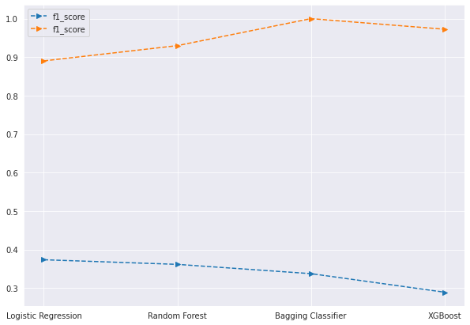

```python
plt.figure(figsize = (10,7))
sns.set_style("darkgrid")
plt.plot(df_metrics['Model'], df_metrics['F1_score'],df_metrics['Train Validation Accuracy'], marker = '>', linestyle='--', label = 'f1_score')
plt.legend(fontsize = 10)
plt.show()
```

# Now using Augmented data

```python
import pickle
```

```python
!git checkout Models
```

```python
!git pull
```

```
Already up to date.
```

```python
infile = open('/content/drive/MyDrive/AIML/Capstone/Train_Test_augment.pickle','rb')
X_train,y_train,X_test,y_test = pickle.load(infile)
```

```python
from sklearn.preprocessing import LabelEncoder
```

```python
infile = open('/content/drive/MyDrive/AIML/Capstone/parameters.pickle','rb')
```

```python
le,tok = pickle.load(infile)
```

```python
y = industry_df['Potential_Accident_Level']
le = LabelEncoder()
le.fit(y)
```

```
LabelEncoder()
```

```python
print(y_train)
```

```
[[0. 0. 1. 0. 0.]
 [0. 1. 0. 0. 0.]
 [0. 0. 1. 0. 0.]
 ...
 [0. 0. 0. 1. 0.]
 [0. 0. 0. 1. 0.]
 [0. 0. 0. 0. 1.]]
```

```python
import numpy as np
```

```python
y_train_n = np.argmax(y_train,axis = 1)
```

```python
y_test_n = np.argmax(y_test,axis = 1)
```

## Now we build all ML models and again re-run the hyperparameter tuning and compare

```python
ml_models(X_train, y_train_n, X_test, y_test_n)
```

|  | model | accuracy |
| --- | --- | --- |
| 0 | LogReg | 0.168675 |
| 1 | Naive Bayes | 0.240964 |
| 2 | KNN | 0.204819 |
| 3 | SVM | 0.337349 |
| 4 | Decision Tree | 0.313253 |
| 5 | RandomForest | 0.325301 |
| 6 | Bagging | 0.301205 |
| 7 | AdaBoost | 0.277108 |
| 8 | Gradient Boost | 0.325301 |
| 9 | XGBoost | 0.301205 |

```python
best_params, rf_gscv, score_gscv = RF_grid_search(X_train, y_train_n,4)
print(best_params)
acc_RF_gs_aug = score_gscv

acc_val_RF_gs_aug = rf_gscv.score(X_test,y_test_n)
predictions_RF_gs_aug = rf_gscv.predict(X_test)
f1_RF_gs_aug = f1_score(y_test_n,predictions_RF_gs_aug, average='micro')
```

```
{'criterion': 'entropy', 'max_depth': 15, 'n_estimators': 100}
```

```python
print(f1_RF_gs_aug)
```

```
0.3373493975903614
```

```python
print(acc_RF_gs_aug, acc_val_RF_gs_aug)
```

```
1.0 0.3373493975903614
```

```python
print(classification_report(y_test_n, predictions_RF_gs_aug))
```

```
              precision    recall  f1-score   support

           0       0.00      0.00      0.00         9
           1       0.29      0.23      0.26        22
           2       0.26      0.45      0.33        20
           3       0.45      0.45      0.45        31
           4       0.00      0.00      0.00         1

    accuracy                           0.34        83
   macro avg       0.20      0.23      0.21        83
weighted avg       0.31      0.34      0.32        83
```

```python
### Now for BAgging classifier
```

```python
best_params, bg_gscv_aug, score_gscv_aug = Bag_grid_search(X_train, y_train_n,4)
print(best_params)
acc_BG_gs_aug = score_gscv_aug
acc_val_BG_gs_aug = bg_gscv_aug.score(X_test,y_test_n)
predictions_BG_gs_aug = bg_gscv_aug.predict(X_test)
f1_BG_gs_aug = f1_score(y_test_n,predictions_BG_gs_aug, average='micro')
```

```
{'n_estimators': 200}
```

```python
print(f1_BG_gs_aug)
```

```
0.3493975903614458
```

```python
print(acc_BG_gs_aug, acc_val_BG_gs_aug)
```

```
1.0 0.3493975903614458
```

```python
print(classification_report(y_test_n, predictions_BG_gs_aug))
```

```
              precision    recall  f1-score   support

           0       0.00      0.00      0.00         9
           1       0.25      0.23      0.24        22
           2       0.31      0.55      0.39        20
           3       0.50      0.42      0.46        31
           4       0.00      0.00      0.00         1

    accuracy                           0.35        83
   macro avg       0.21      0.24      0.22        83
weighted avg       0.33      0.35      0.33        83
```

```python
### Using XGBoost
```

```python
best_params, xg_gscv_aug, score_gscv_aug = XGBoost_grid_search(X_train, y_train_n,4)
print(best_params)
acc_XG_gs_aug = score_gscv_aug
acc_val_XG_gs_aug = xg_gscv_aug.score(X_test,y_test_n)
predictions_XG_gs_aug = xg_gscv_aug.predict(X_test)
f1_XG_gs_aug = f1_score(y_test_n,predictions_XG_gs_aug, average='micro')
```

```
{'learning_rate': 0.1, 'max_depth': 5, 'n_estimators': 200}
```

```python
print(f1_XG_gs_aug)
```

```
0.3132530120481928
```

```python
print(acc_XG_gs_aug, acc_val_XG_gs_aug)
```

```
1.0 0.3132530120481928
```

```python
print(classification_report(y_test_n, predictions_XG_gs_aug))
```

```
              precision    recall  f1-score   support

           0       0.00      0.00      0.00         9
           1       0.37      0.32      0.34        22
           2       0.23      0.40      0.29        20
           3       0.42      0.35      0.39        31
           4       0.00      0.00      0.00         1

    accuracy                           0.31        83
   macro avg       0.20      0.21      0.20        83
weighted avg       0.31      0.31      0.30        83
```

```python
## Using Logistic Regression
```

```python
best_params, lr_gscv_aug, score_gscv_aug = LR_grid_search(X_train, y_train_n,4)
print(best_params)
acc_LR_gs_aug = score_gscv_aug
acc_val_LR_gs_aug = lr_gscv_aug.score(X_test,y_test_n)
predictions_LR_gs_aug = lr_gscv_aug.predict(X_test)
f1_LR_gs_aug = f1_score(y_test_n,predictions_LR_gs_aug, average='micro')
```

```
{'penalty': 'l2', 'solver': 'saga'}
```

```python
print(f1_LR_gs_aug)
```

```
0.2289156626506024
```

```python
print(acc_LR_gs_aug, acc_val_LR_gs_aug)
```

```
0.6448170731707317 0.2289156626506024
```

```python
print(classification_report(y_test_n, predictions_LR_gs_aug))
```

```
              precision    recall  f1-score   support

           0       0.17      0.22      0.19         9
           1       0.33      0.36      0.35        22
           2       0.12      0.10      0.11        20
           3       0.32      0.23      0.26        31
           4       0.00      0.00      0.00         1

    accuracy                           0.23        83
   macro avg       0.19      0.18      0.18        83
weighted avg       0.26      0.23      0.24        83
```

## Plotting the graph and comparing

```python
d = {'Model': ['Logistic Regression','Random Forest', 'Bagging Classifier','XGBoost','Logistic Regression_Aug','Random Forest_Aug', 'Bagging Classifier_Aug','XGBoost_Aug'],
          'F1_score':[f1_LR_gs, f1_RF_gs, f1_BG_gs, f1_XG_gs,f1_LR_gs_aug, f1_RF_gs_aug, f1_BG_gs_aug, f1_XG_gs_aug],
          'Train Validation Accuracy':[acc_LR_gs, acc_RF_gs, acc_BG_gs, acc_XG_gs,acc_LR_gs_aug, acc_RF_gs_aug, acc_BG_gs_aug, acc_XG_gs_aug] }

#df_metrics = pd.DataFrame(d)

print(d)
```

[output not shown]

```python
df_metrics = pd.DataFrame(d)
df_metrics
```

|  | Model | F1_score | Train Validation Accuracy |
| --- | --- | --- | --- |
| 0 | Logistic Regression | 0.373494 | 0.890244 |
| 1 | Random Forest | 0.361446 | 0.929878 |
| 2 | Bagging Classifier | 0.337349 | 1.000000 |
| 3 | XGBoost | 0.289157 | 0.972561 |
| 4 | Logistic Regression_Aug | 0.228916 | 0.644817 |
| 5 | Random Forest_Aug | 0.337349 | 1.000000 |
| 6 | Bagging Classifier_Aug | 0.349398 | 1.000000 |
| 7 | XGBoost_Aug | 0.313253 | 1.000000 |

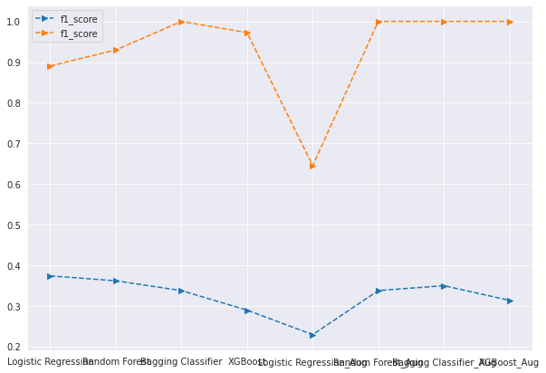

```python
plt.figure(figsize = (10,7))
sns.set_style("darkgrid")
plt.plot(df_metrics['Model'], df_metrics['F1_score'],df_metrics['Train Validation Accuracy'], marker = '>', linestyle='--', label = 'f1_score')
plt.legend(fontsize = 10)
plt.show()
```

Final Observations: